# Example of how to load an Allen Database cell into the single cell module

## Load the Allen Database cell

To use the Allen cell with bmtool we need to use the load_allen_database_cells function. This will load the cell into a format that bmtool can use

```python
import matplotlib.pyplot as plt

from bmtool.singlecell import CurrentClamp, Profiler, load_allen_database_cells, run_and_plot

cell_creater = load_allen_database_cells(morphology=morphology,
                                 dynamic_params=dynamic_params,
                                 model_processing='aibs_allactive')
```

Now we can use this cell_creater in a similar way to the cell template name in the Neuron_hoc tutorial.

```python
profiler = Profiler(template_dir='.', mechanism_dir = 'modfiles', dt=0.1)

sim = CurrentClamp(cell_creater, inj_amp=500., inj_delay=1500., inj_dur=1000., tstop=3000., threshold=-15.)

X, Y = run_and_plot(sim, title='Current Injection', xlabel='Time (ms)',
                    ylabel='Membrane Potential (mV)', plot_injection_only=True)
plt.show()
```

```
NEURON mechanisms not found in modfiles.
Injection location: Biophys1[0].soma[0](0.5)
Recording: Biophys1[0].soma[0](0.5)._ref_v
Current clamp simulation running...

Number of spikes: 15
```

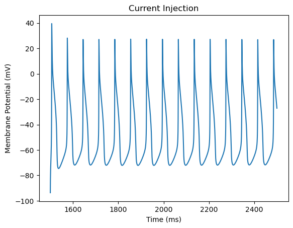

```python
from bmtool.singlecell import FI

sim = FI(cell_creater,tdur=1000,i_increment=50)
X, Y = run_and_plot(sim,xlabel='Current',ylabel="Spikes")
plt.show()
```

```
Injection location: Biophys1[21].soma[0](0.5)
Recording: Biophys1[21].soma[0](0.5)._ref_v
Running simulations for FI curve...

Results
    Injection (nA):  number of spikes
0              0.00                 0
1              0.05                 0
2              0.10                 2
3              0.15                 6
4              0.20                 9
5              0.25                11
6              0.30                12
7              0.35                13
8              0.40                14
9              0.45                14
10             0.50                15
11             0.55                15
12             0.60                15
13             0.65                15
14             0.70                 5
15             0.75                 4
16             0.80                 3
17             0.85                 3
18             0.90                 2
19             0.95                 2
20             1.00                 2
```

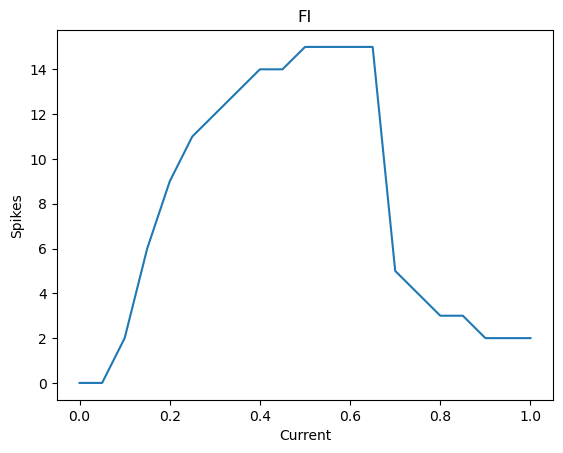